# Problem Set 14

Your Name Here

Last updated: 2019-04-28

```r
# FIXME
library(readxl)
library(tidyverse)
library(cowplot)
library(pwr)
```

## Planning experiments

Consider that you are planning some experiments, use the `pwr` package to calculate the unknown quantity for each of the following situations. Assume that $\alpha$ = 0.05 for all tests.

### Activity

Use `cohen.ES()` to look up the effect size for a “small” effect for a *t*-test.

```r
# FIXME
cohen.ES(test = "t", size = "small")
```

```
##
##      Conventional effect size from Cohen (1982)
##
##            test = t
##            size = small
##     effect.size = 0.2
```

Calculate the sample size (*n*) needed in each group of a two-sample *t*-test with power = 0.80 to detect a small effect (use the effect size from above).

```r
# FIXME
pwr.t.test(d = 0.2, power = 0.80, type = "two.sample")
```

```
##
##      Two-sample t test power calculation
##
##               n = 393.4057
##               d = 0.2
##       sig.level = 0.05
##           power = 0.8
##     alternative = two.sided
##
## NOTE: n is number in *each* group
```

Repeat the test above but for a paired *t*-test.

```r
# FIXME
pwr.t.test(d = 0.2, power = 0.80, type = "paired")
```

```
##
##      Paired t test power calculation
##
##               n = 198.1508
##               d = 0.2
##       sig.level = 0.05
##           power = 0.8
##     alternative = two.sided
##
## NOTE: n is number of *pairs*
```

Calculate the number of observations for a correlation test where you estimate a correlation coefficient of 0.6. Power should be 0.80.

```r
# FIXME
pwr.r.test(r = 0.6, power = 0.8)
```

```
##
##      approximate correlation power calculation (arctangh transformation)
##
##               n = 18.63858
##               r = 0.6
##       sig.level = 0.05
##           power = 0.8
##     alternative = two.sided
```

Calculate the power for a correlation test where you estimate the correlation coefficient to be 0.4, for a sample size of 15.

```r
# FIXME
pwr.r.test(r = 0.4, n = 15)
```

```
##
##      approximate correlation power calculation (arctangh transformation)
##
##               n = 15
##               r = 0.4
##       sig.level = 0.05
##           power = 0.3262493
##     alternative = two.sided
```

## Calcium concentration in bird plasma

The file `Bird_Plasma.xlsx` contains factorial data on blood plasma calcium concentration (`Calcium`, mg / 100 mL) in male and female birds (`Sex`) each of which was treated or not with a hormone (`Hormone`).

### Activity

Load the Excel file, and convert treatment and sex to factors.

```r
# FIXME
M <- read_excel("../data/Bird_Plasma.xlsx")
M <- M %>% mutate(Treatment = factor(Treatment),
                  Sex = factor(Sex))
```

Use `group_by()` and `tally()` to determine the sample size in each of the groups.

```r
# FIXME
M %>% group_by(Treatment, Sex) %>% tally()
```

```
## # A tibble: 4 x 3
## # Groups:   Treatment [2]
##   Treatment Sex        n
##   <fct>     <fct>  <int>
## 1 Hormone   Female     5
## 2 Hormone   Male       5
## 3 None      Female     5
## 4 None      Male       5
```

Assume that the researchers who carried out this study had performed a power analysis prior to collecting data. Calculate the minimum effect size for a main effect they could detect with their experimental design if they use an ANOVA to analyze the data. Assume that there are 4 groups and power is 0.80.

```r
# FIXME
pwr.anova.test(k = 4, n = 5, power = 0.80)
```

```
##
##      Balanced one-way analysis of variance power calculation
##
##               k = 4
##               n = 5
##               f = 0.8352722
##       sig.level = 0.05
##           power = 0.8
##
## NOTE: n is number in each group
```

How do you interpret the minimum effect size that the researchers could detect at power of 0.8?

> The effect has to be really large (> 0.8 standard deviations) in order to detect it.

## Power via simulation

A more appropriate way to analyze the bird plasma data is to use a factorial ANOVA (both main effects and their interaction term). Imagine that you are planning just such an experiment:

- Two treatment groups which each have two levels (a 2 X 2 design)
- n = 5 in each group
- Your alpha will be 0.05
- You are interested in detecting main effects and interactions (full factorial model)

We will simulate data where the main effect of one term varies and the interaction effect varies, figure out the power across a range of different means, and make the assumption that within-group standard deviations are equal at 4 and the main effect of the other variable does not change (for now). We will build up this simulation in steps, first considering one parameter combination and one iteration before setting up the entire simulation.

1. Generate two vectors, which will represent the range of differences in treatment and the range of differences for the interaction. For now, test from -10 to 10, with 10 steps in between.

The `tidyr` package, which is loaded with `tidyverse` has a handy function `crossing()`, which will expand vectors with all pairwise combinations into a `tibble`. Use this function to cross the vectors. You should have a 100 X 2 `tibble`.

```r
# FIXME
low <- -10
high <- 10
length.out <- 10

diffs_tx <- seq(low, high, length = length.out)
diffs_int <- seq(low, high, length = length.out)

pwr_sim <- crossing(diffs_tx, diffs_int)
```

Use `mutate()` at add two additional `numeric()` columns, one each for the power to detect a treatment effect and the sex X treatment interaction.

```r
# FIXME
pwr_sim <- pwr_sim %>%
  mutate(tx = logical(length = nrow(pwr_sim)),
         sex_tx = logical(length = nrow(pwr_sim)))
```

2. Let’s start by considering a single parameter combination: the first row of your `tibble` from above. First we will calculate the means for the four groups defined by sex and treatment (you might call these `s0t0`, `s1t0`, `s0t1`, `s1t1`). Assign `s0t0` to have a mean of zero. Because we are focusing only on treatment, we will not simulate a main effect of sex so assign `s1t0` to also have a mean of zero. For the effect of treatment, because we are also simulating an interaction, we need to consider both when assigning the means. That is what an interaction is, the effect of one term is dependent on the state of the other. We will add the effect of the main effect and the interaction effect which will be conditional on sex. So, for `s0t1`, add the effect for treatment to 0.5 multiplied by the effect of the interaction. And for `s1t1`, add the effect for treatment to -0.5 multiplied by the effect of the interaction. This will create a set of means in which there is an overall main effect for treatment, no main effect for sex, and an interaction effect.

Confirm this by calculating the values for your means.

```r
# FIXME
s0t0 <- 0
s1t0 <- 0
s0t1 <- as.numeric(pwr_sim[1, 1] + 0.5 * pwr_sim[1, 2])
s1t1 <- as.numeric(pwr_sim[1, 1] + -0.5 * pwr_sim[1, 2])

print(c(s0t0, s1t0, s0t1, s1t1))
```

```
## [1]   0   0 -15  -5
```

3. Now that you have code to assign the means for each group, we can move on to simulating one iteration for this parameter combination. We want to generate data for each group from a random normal distribution. All have the same standard deviation (4). Use the sample sizes for the groups defined above. Set up a `data.frame` with these data and labels for the groups (think about how `lm()` will need the data to be formatted). Then we will fit the ANOVA using `anova(lm())` and assign a TRUE/FALSE for the treatment term and interaction term that will tell us whether it is significant or not at our alpha level.

```r
# FIXME
s0t0 <- 0
s1t0 <- 0
s0t1 <- as.numeric(pwr_sim[10, 1] + 0.5 * pwr_sim[10, 2])
s1t1 <- as.numeric(pwr_sim[10, 1] + -0.5 * pwr_sim[10, 2])
stdev <- 4
nn <- 5
alpha <- 0.05

y_sex0_tx0 <- rnorm(nn, mean = s0t0, sd = stdev)
y_sex1_tx0 <- rnorm(nn, mean = s1t0, sd = stdev)
y_sex0_tx1 <- rnorm(nn, mean = s0t1, sd = stdev)
y_sex1_tx1 <- rnorm(nn, mean = s1t1, sd = stdev)

D <- tibble(Calcium = c(y_sex0_tx0, y_sex1_tx0,
                        y_sex0_tx1, y_sex1_tx1),
            sex = factor(rep(c("F", "M", "F", "M"), each = nn)),
            tx = factor(rep(c("None", "Hormone"), each = nn * 2)))

fm <- anova(lm(Calcium ~ sex * tx, data = D))
fm
```

```
## Analysis of Variance Table
##
## Response: Calcium
##           Df Sum Sq Mean Sq F value    Pr(>F)
## sex        1 105.51  105.51  6.0477   0.02569 *
## tx         1 470.96  470.96 26.9953 8.839e-05 ***
## sex:tx     1   8.86    8.86  0.5077   0.48641
## Residuals 16 279.13   17.45
## ---
## Signif. codes:  0 '***' 0.001 '**' 0.01 '*' 0.05 '.' 0.1 ' ' 1
```

```r
p_tx <- fm$`Pr(>F)`[2] < alpha
p_sex_tx <- fm$`Pr(>F)`[3] < alpha
```

4. You now have all of the code you need to do the simulation. You just need to set it up with two loops. You want to loop through each of your parameter combinations. Then, for each combination, you want to loop through several iterations. First set this up with a small number of iterations. Then scale up to 1000.

Use `Sys.time()` to get a sense for how long your program will run when you scale up. Start by assigning the output of `Sys.time()` to a variable before you loop starts (`t_start <- Sys.time()`). After your loop, subtract that from `Sys.time()` (e.g., `Sys.time() - t_start`).

```r
set.seed(2238746)
niter <- 1000
alpha <- 0.05
nn <- 5
stdev <- 4

t1 <- Sys.time()

for (ii in 1:nrow(pwr_sim)) {
  s0t0 <- 0
  s1t0 <- 0
  s0t1 <- as.numeric(pwr_sim[ii, 1] + 0.5 * pwr_sim[ii, 2])
  s1t1 <- as.numeric(pwr_sim[ii, 1] + -0.5 * pwr_sim[ii, 2])

  for (jj in 1:niter) {

    y_sex0_tx0 <- rnorm(nn, mean = s0t0, sd = stdev)
    y_sex1_tx0 <- rnorm(nn, mean = s1t0, sd = stdev)
    y_sex0_tx1 <- rnorm(nn, mean = s0t1, sd = stdev)
    y_sex1_tx1 <- rnorm(nn, mean = s1t1, sd = stdev)

    D <- tibble(Calcium = c(y_sex0_tx0, y_sex1_tx0,
                            y_sex0_tx1, y_sex1_tx1),
                sex = factor(rep(c("F", "M", "F", "M"), each = nn)),
                tx = factor(rep(c("None", "Hormone"), each = nn * 2)))

    fm <- anova(lm(Calcium ~ sex * tx, data = D))

    p_tx[jj] <- fm$`Pr(>F)`[2] < alpha
    p_sex_tx[jj] <- fm$`Pr(>F)`[3] < alpha
  }
  pwr_sim$tx[ii] <- mean(p_tx)
  pwr_sim$sex_tx[ii] <- mean(p_sex_tx)
}
Sys.time() - t1
```

```
## Time difference of 10.69975 mins
```

```r
save(pwr_sim, file = "pwr_sim.Rda")
```

5. Now we want to visualize the results. Make separate plots of with your sets of differences for the treatment and for the interaction on the x and y axes. Color the points by the power associated with the treatment effect in the first plot and by the power associated with the interaction effect in the second. The output should look like a grid of points (one for each combination of values) that are color coded by power. This is a kind of manual heatmap.

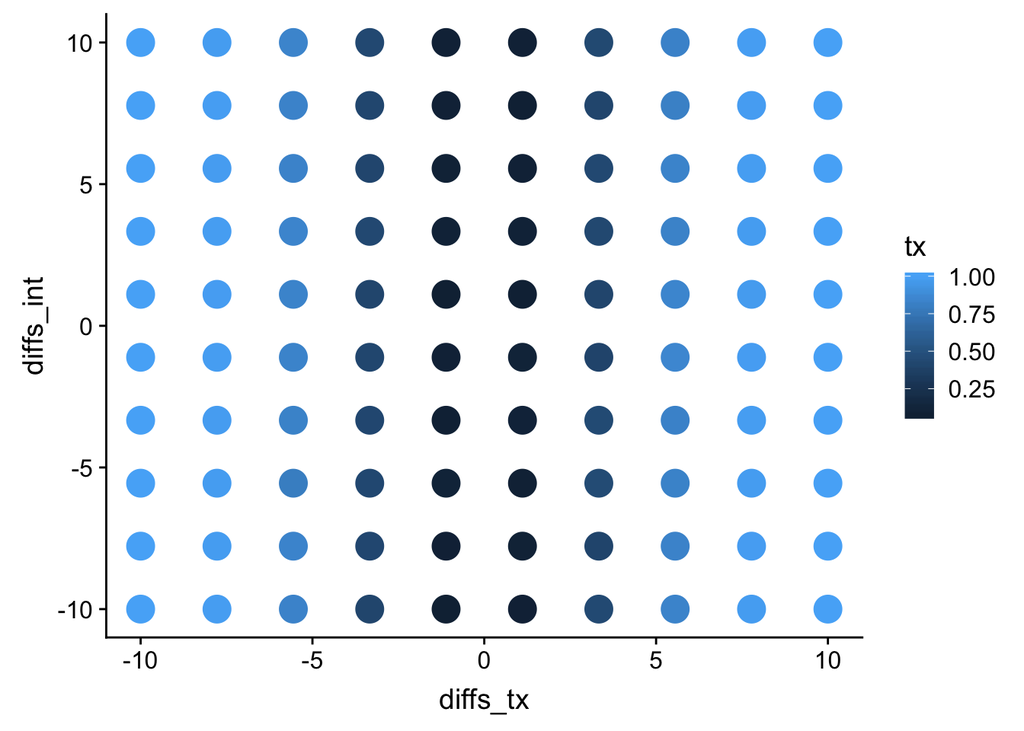

```r
load("pwr_sim.Rda")

ggplot(pwr_sim, aes(x = diffs_tx, y = diffs_int, color = tx)) +
  geom_point(size = 6)
```

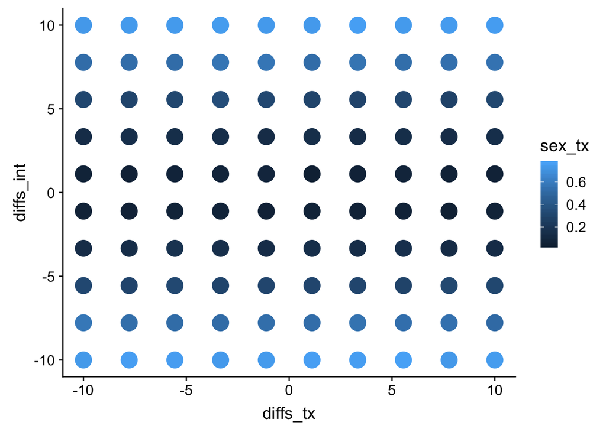

```r
ggplot(pwr_sim, aes(x = diffs_tx, y = diffs_int, color = sex_tx)) +
  geom_point(size = 6)
```

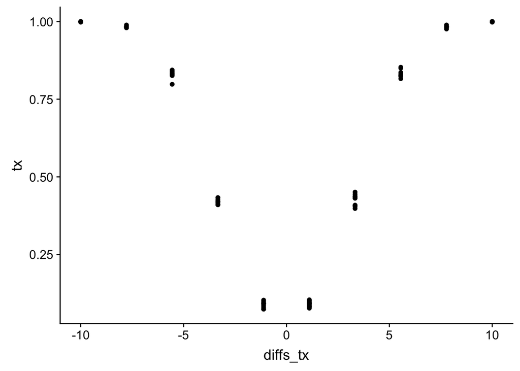

```r
ggplot(pwr_sim, aes(x=diffs_tx, y=tx)) +
  geom_point()
```

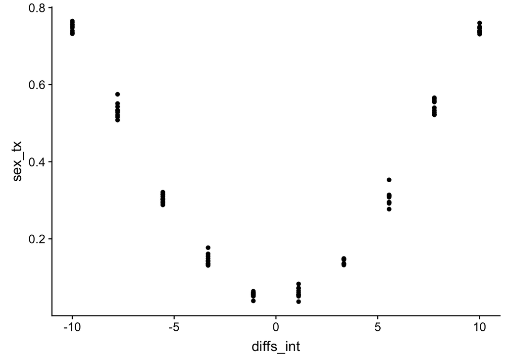

```r
ggplot(pwr_sim, aes(x=diffs_int, y=sex_tx)) +
  geom_point()
```